# Этап индивидуального проекта №3

Операционные системы

Дворкина Ева Владимировна

Российский университет дружбы народов, Москва, Россия

7 апреля 2023

## Докладчик

- Дворкина Ева Владимировна
- студентка из группы НКАбд-01-22
- Факультет физико-математических и естественных наук
- Российский университет дружбы народов
- 1132226447@rudn.ru
- https:///evdvorkina.github.io

## Цель работы

Продолжить работы со своим сайтом. Редактировать его в соответствии с требованиями. Добавить данные о своих достижениях.

## Задание

1. Добавить информацию о навыках (Skills).
2. Добавить информацию об опыте (Experience).
3. Добавить информацию о достижениях (Accomplishments).
4. Сделать пост по прошедшей неделе.
5. Добавить пост на тему по выбору.

## Выполнение проекта

Захожу в терминал, перехожу в директорию ~/work/blog, ввожу команду ~/bin/hugo server для запуска локального сервера

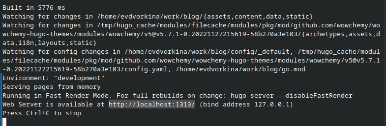

Запуск локального сервера

## Выполнение проекта

Перехожу в директорию ~/work/blog/content, открываю файл _index.md, в нем будет осуществляться дальшейшая работа

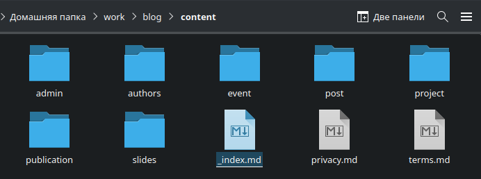

Путь, по которому работаем

## Выполнение проекта

В блоке features, там, где заголовок Skills прописала навыки. Иконки для навыков искала, найдя в интернете официальную библиотеку иконок fas, так можно найти и иконки из библиотеки fab

[figure not shown]

Добавление навыков

## Выполнение проекта

Далее добавила свой опыт в блоке Experience, указала ссылки на компанию, в которой успела получить опыт работы, добавила даты, поменяла иконки

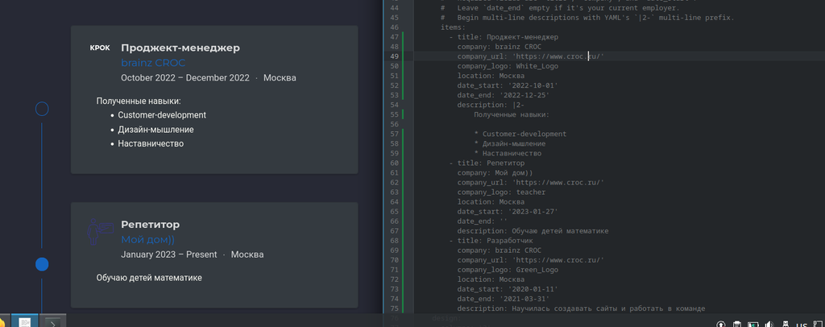

Добавление опыта

## Выполнение проекта

Чтобы поменять иконки, я скачала изображения формата .svg и поместила их в директорию ~work/blog/assets/media/icons/brands

[figure not shown]

Добавление иконок

## Выполнение проекта

Далее в Accomplishments добавила достижения

[figure not shown]

Добавление достижений

## Выполнение проекта

Добавила пост на тему по выбору (язык разметки Markdown) в папке posts

[figure not shown]

Добавление поста на тему по выбору

## Выполнение проекта

Добавила пост по прошедшей неделе в папке posts

[figure not shown]

Добавление поста по прошедшей неделе

## Выполнение проекта

Закрываю локальный сервер с помощью клавиш Ctrl+C и собираю сайт с изменениями, введя команду ~/bin/hugo без аргументов

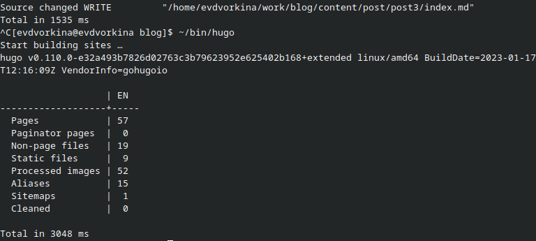

Закрытие локального сервера

## Выполнение проекта

Отправляю изменения на GitHub

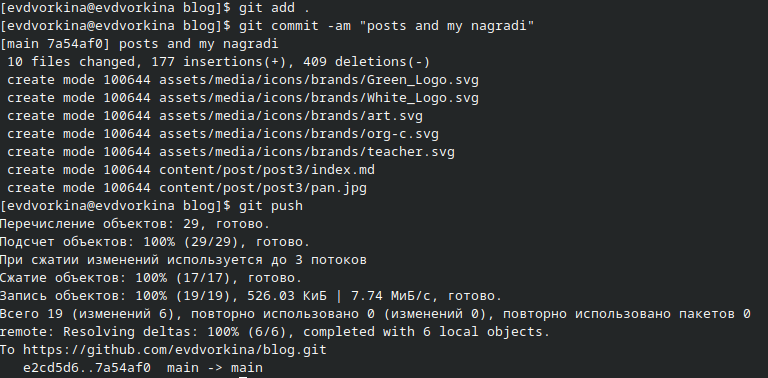

Отправка изменений на Git

## Выполнение проекта

Теперь перехожу в директорию blog/public и отправляю изменения на GitHub, чтобы глобальный сайт тоже был обновлен

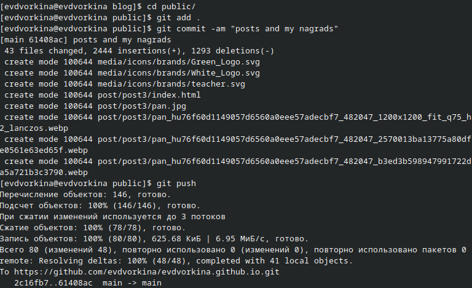

Отправка изменений на Git

## Выполнение проекта

Сайтик:

[figure not shown]

Результат выполнения работы